# Practical Machine Learning 2015: Prediction Assignment Writeup

C.K. Tse

February 21, 2015

This is an R Markdown document for the course project of [Practical Machine Learning](https://class.coursera.org/predmachlearn-011/human_grading/view/courses/973546/assessments/4/submissions) using data made available from the research paper [Qualitative Activity Recognition of Weight Lifting Exercises](http://groupware.les.inf.puc-rio.br/public/papers/2013.Velloso.QAR-WLE.pdf).

### Exploratory Analysis: identifying predictors in the training set

#### Setup environment, load datasets:

```r
library(caret)
library(randomForest)
pml.training = read.csv('/Volumes/wakamatsu-s/dev/escience/r101/pml-training.csv')
pml.testing = read.csv('/Volumes/wakamatsu-s/dev/escience/r101/pml-testing.csv')
```

#### Regarding the lack of summary statistics in the testing dataset:

While section 5.1 of the cited [paper](http://groupware.les.inf.puc-rio.br/public/papers/2013.Velloso.QAR-WLE.pdf) spoke to the selection of 17 features based on summary statistics (e.g. max, range, mean, variance) calculated at the end of each sliding window, the testing dataset given in this project does not contain such summary statistics data nor the raw data for the full window such that these can derived. (Summary statistic columns are provided in the training dataset for the rows with column ‘new_window’ equals ‘yes’, indicating the end of each sliding window. These columns are otherwise ’NA’. All of the ’new_window’ values are ’no’ in the testing dataset, with all of the summary statistic columns equal ‘NA’.)

Given this limitation, unlike the original paper, we cannot rely on the summary statistics columns for feature extraction but rather on the raw data columns instead.

Here’s a quick way to identify all of the NA summary statistics columns in the training dataset and drop them off:

```r
df = pml.training
drops = nearZeroVar(df[df$new_window != 'yes', ])
df = df[, -drops]
```

#### Drop remaining columns from training set which aren’t relevant to feature extractions:

e.g. user name, timestamps (not useful given the training dataset per above).

```r
drops2 = c('X', 'user_name', 'raw_timestamp_part_1', 'raw_timestamp_part_2', 'cvtd_timestamp', 'num_window')
df = df[, !(names(df) %in% drops2)]
```

The remaining columns will be used as predicators in model building, i.e. 52 predictors.

#### Split into training + validation set, 70% random sampling:

```r
inTrain = createDataPartition(y=df$classe, p=0.7, list=FALSE)
training = df[inTrain, ]
testing = df[-inTrain, ]
```

### Model Training

#### Train random forest model with 10-fold cross-validation:

```r
model = train(classe~., training, method='rf', trControl=trainControl(method="cv", number=10), allowParallel=TRUE)
```

#### Check model accuracy on training set:

```r
model
```

```
## Random Forest
##
## 13737 samples
##    52 predictor
##     5 classes: 'A', 'B', 'C', 'D', 'E'
##
## No pre-processing
## Resampling: Cross-Validated (10 fold)
##
## Summary of sample sizes: 12362, 12365, 12364, 12365, 12365, 12364, ...
##
## Resampling results across tuning parameters:
##
##   mtry  Accuracy  Kappa  Accuracy SD  Kappa SD
##    2    0.993     0.991  0.00156      0.00197
##   27    0.991     0.989  0.00304      0.00385
##   52    0.985     0.981  0.00312      0.00395
##
## Accuracy was used to select the optimal model using  the largest value.
## The final value used for the model was mtry = 2.
```

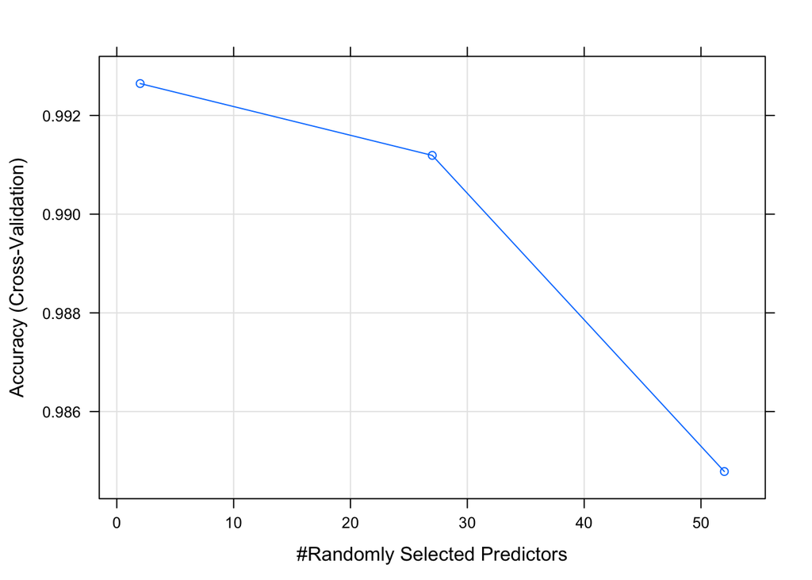

```r
plot(model)
```

##### Check model accuracy on validation set:

```r
pv = predict(model, testing)
cm = confusionMatrix(pv, testing$classe)
cm
```

```
## Confusion Matrix and Statistics
##
##           Reference
## Prediction    A    B    C    D    E
##          A 1674    5    0    0    0
##          B    0 1130   12    0    0
##          C    0    4 1014   21    0
##          D    0    0    0  942    1
##          E    0    0    0    1 1081
##
## Overall Statistics
##
##                Accuracy : 0.9925
##                  95% CI : (0.99, 0.9946)
##     No Information Rate : 0.2845
##     P-Value [Acc > NIR] : < 2.2e-16
##
##                   Kappa : 0.9905
##  Mcnemar's Test P-Value : NA
##
## Statistics by Class:
##
##                      Class: A Class: B Class: C Class: D Class: E
## Sensitivity            1.0000   0.9921   0.9883   0.9772   0.9991
## Specificity            0.9988   0.9975   0.9949   0.9998   0.9998
## Pos Pred Value         0.9970   0.9895   0.9759   0.9989   0.9991
## Neg Pred Value         1.0000   0.9981   0.9975   0.9955   0.9998
## Prevalence             0.2845   0.1935   0.1743   0.1638   0.1839
## Detection Rate         0.2845   0.1920   0.1723   0.1601   0.1837
## Detection Prevalence   0.2853   0.1941   0.1766   0.1602   0.1839
## Balanced Accuracy      0.9994   0.9948   0.9916   0.9885   0.9994
```

i.e. accuracy rate of 99.25%, i.e. error rate of 0.75% on the validation set.

### Run predictions on the original testing set:

```r
p = predict(model, pml.testing)
p
```

```
##  [1] B A B A A E D B A A B C B A E E A B B B
## Levels: A B C D E
```

### Opportunity to simplify model

Given the very high accuracy rate, we want to look for opportunity to simplify the model by eliminating predictors which are highly correlated to the others, with absolute correlation cutoff set at 0.75:

```r
M = cor(training[,-53])
drop3 = findCorrelation(M, cutoff=0.75)
colnames(training[drop3])
```

```
##  [1] "accel_belt_z"      "roll_belt"         "accel_arm_y"
##  [4] "accel_belt_y"      "total_accel_belt"  "accel_dumbbell_z"
##  [7] "accel_belt_x"      "pitch_belt"        "magnet_dumbbell_x"
## [10] "accel_dumbbell_y"  "magnet_dumbbell_y" "accel_dumbbell_x"
## [13] "accel_arm_x"       "accel_arm_z"       "magnet_arm_y"
## [16] "magnet_belt_y"     "accel_forearm_y"   "gyros_arm_y"
```

This reduce the number of predictors in the model to 34 from 52.

#### Re-train random forest model with 10-fold cross validation, using the remaining predictors:

```r
trainingSS = training[, -drop3]
model2 = train(classe~., trainingSS, method='rf', trControl=trainControl(method="cv", number=10), allowParallel=TRUE)
```

#### Check revised model accuracy on training set:

```r
model2
```

```
## Random Forest
##
## 13737 samples
##    34 predictor
##     5 classes: 'A', 'B', 'C', 'D', 'E'
##
## No pre-processing
## Resampling: Cross-Validated (10 fold)
##
## Summary of sample sizes: 12363, 12363, 12364, 12363, 12364, 12363, ...
##
## Resampling results across tuning parameters:
##
##   mtry  Accuracy  Kappa  Accuracy SD  Kappa SD
##    2    0.990     0.988  0.00365      0.00462
##   18    0.989     0.986  0.00328      0.00415
##   34    0.982     0.977  0.00452      0.00573
##
## Accuracy was used to select the optimal model using  the largest value.
## The final value used for the model was mtry = 2.
```

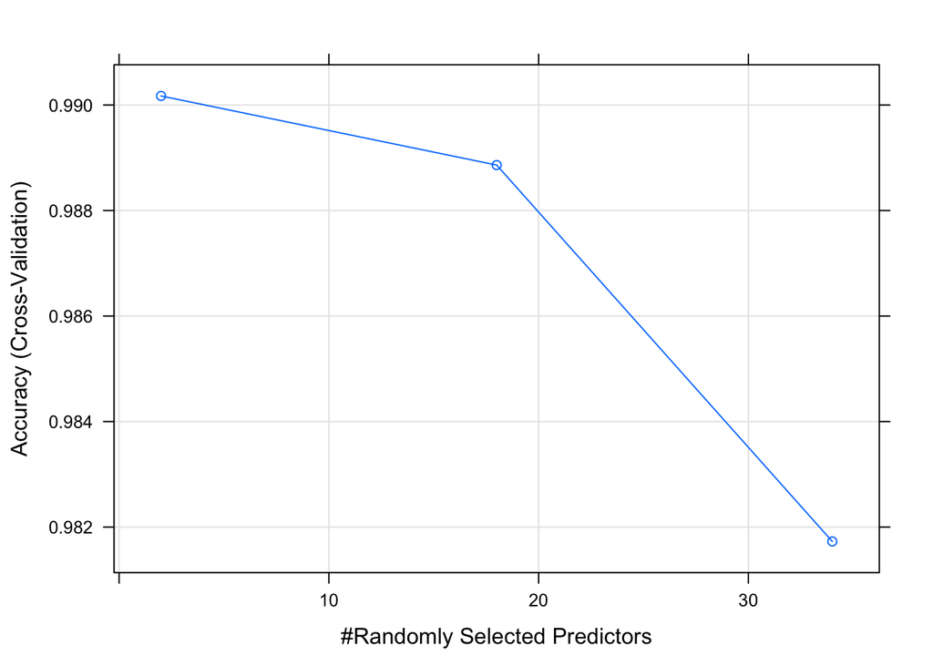

```r
plot(model2)
```

#### Check revised model accuracy on validation set:

```r
pv = predict(model2, testing)
cm = confusionMatrix(pv, testing$classe)
cm
```

```
## Confusion Matrix and Statistics
##
##           Reference
## Prediction    A    B    C    D    E
##          A 1673    3    0    0    0
##          B    0 1132   12    0    0
##          C    0    4 1010   16    0
##          D    0    0    4  947    1
##          E    1    0    0    1 1081
##
## Overall Statistics
##
##                Accuracy : 0.9929
##                  95% CI : (0.9904, 0.9949)
##     No Information Rate : 0.2845
##     P-Value [Acc > NIR] : < 2.2e-16
##
##                   Kappa : 0.991
##  Mcnemar's Test P-Value : NA
##
## Statistics by Class:
##
##                      Class: A Class: B Class: C Class: D Class: E
## Sensitivity            0.9994   0.9939   0.9844   0.9824   0.9991
## Specificity            0.9993   0.9975   0.9959   0.9990   0.9996
## Pos Pred Value         0.9982   0.9895   0.9806   0.9947   0.9982
## Neg Pred Value         0.9998   0.9985   0.9967   0.9966   0.9998
## Prevalence             0.2845   0.1935   0.1743   0.1638   0.1839
## Detection Rate         0.2843   0.1924   0.1716   0.1609   0.1837
## Detection Prevalence   0.2848   0.1944   0.1750   0.1618   0.1840
## Balanced Accuracy      0.9993   0.9957   0.9901   0.9907   0.9993
```

i.e. accuracy rate of 99.29%, i.e. error rate of 0.71% on the validation set.

### Revised model predictions on the original testing set:

```r
p2 = predict(model2, pml.testing)
p2 == p
```

```
##  [1] TRUE TRUE TRUE TRUE TRUE TRUE TRUE TRUE TRUE TRUE TRUE TRUE TRUE TRUE
## [15] TRUE TRUE TRUE TRUE TRUE TRUE
```

The simplified model turns out to be working very well compared to the original one. Indeed, they both generate exactly the same predictions on the testing set.

Q.E.D.